# 210_lab4

### 1) Truffles

**Truffles are a great delicacy, sending thousands of mushroom hunters into the forest each fall to find them. A set of plots of equal size in an old-growth forest in Northern California was surveyed to count the number of truffles (Waters et al., 1997). The resulting distribution is presented in the following table. Are truffles randomly located around the forest? How can you tell? (The mean number of truffles per plot, calculated from these data, is 0.60).**

```r
truffles <- data.frame(count = c("0","1","2","3",">3"),
                       freq = c(203, 39, 18, 13, 15))
```

If the truffles were randomly distributed we would expect these data to fit a Poisson distribution. We’ll build an expected/actual value table and run a chi-squared test.

```r
truffles$expected <- dpois(c(0,1,2,3,4), 0.6) # first set of values are from probabiltiy density function
truffles[5,]$expected <- (1-ppois(4,0.6))     # last value is an upper tail cumulative probability

truffle_test <- chisq.test(truffles$freq, p=truffles$expected/sum(truffles$expected))
```

Based on our test, we **are able to reject the null hypothesis that truffles are distributed randomly** in this forest ($\chi^2$(4) = 2003.4626044, p-value = 0).

### 2)

**The following list gives the number of degrees of freedom and the $\chi^2$ test statistic for several goodness-of-fit test. Find the P-value for each test.**

```r
chisq_table <- data.frame(df = c(1,4,2,10,1),
                          chisq = c(4.12,1.02,9.50,12.40,2.48))
chisq_table$p_val <- dchisq(chisq_table$chisq, df=chisq_table$df)

kable(chisq_table) %>% kable_styling()
```

| df | chisq | p_val |
| --- | --- | --- |
| 1 | 4.12 | 0.0250504 |
| 4 | 1.02 | 0.1531264 |
| 2 | 9.50 | 0.0043258 |
| 10 | 12.40 | 0.0624741 |
| 1 | 2.48 | 0.0733093 |

### 3) Soccer

**Soccer reaches its apex every four years at the World Cup, attracting worldwide attention and fanatic devotion. The World Cup is widely thought to be the event that decides the best soccer team in the world. But how much do skill differences determine the outcome? If the probability ofa goal is the same for all teams and games, and if goals are independent, then we would expect the frequency distribution of goals per game to approximate a Poisson distribution. In contrast, if skill differences really matter, then we would expect more high scores and more low scores than predicted from the Poisson distribution. The following table tallies the number of goals scored by one of the two teams (randomly chosen) in every game of the knockout round of the World Cup from 1986 through 2010.**

```r
soccer <- data.frame(goals = c("0","1","2","3","4","5",">5"),
                     freq = c(37,44,21,10,4,1,0))

kable(soccer) %>% kable_styling()
```

| goals | freq |
| --- | --- |
| 0 | 37 |
| 1 | 44 |
| 2 | 21 |
| 3 | 10 |
| 4 | 4 |
| 5 | 1 |
| >5 | 0 |

#### a) Plot the frequency distribution of goals per team using the data in the table.

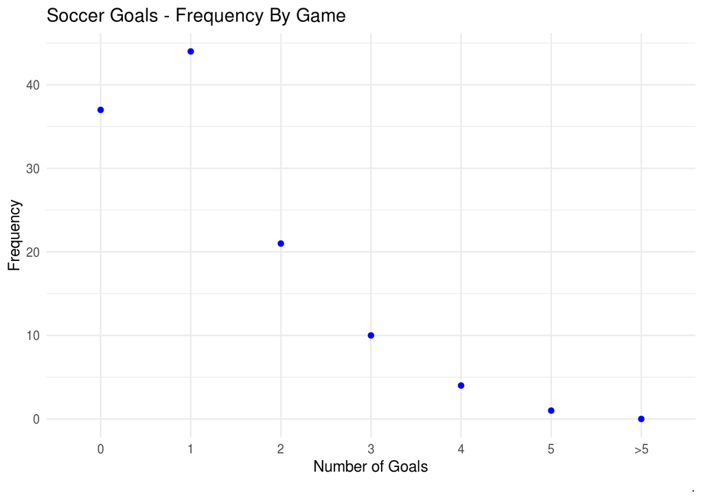

```r
ggplot(data = soccer) +
  geom_point(aes(x = goals, y = freq),
            col = "blue") +
  theme_minimal() +
  ggtitle("Soccer Goals - Frequency By Game") +
  xlab("Number of Goals") +
  ylab("Frequency") +
  labs(caption = ".")
```

#### b) What is the mean number of goals per game?

```r
mean_goals <- sum(0:5 * soccer$freq)/sum(soccer$freq)
```

The mean number of goals per game per side is 1.1709402. Because there are two teams in each game, the mean number of total goals in each game is **2.3418803**.

#### c) Using the Poisson distribution, calculate the expected frequency of games and teams with 0, 1, 2, ….,5 goals, assuming independence and equal probability of scoring.

```r
soccer$expected <- dpois(0:6, mean_goals)*sum(soccer$freq)
soccer[7,]$expected <- (1 - ppois(5, mean_goals))*sum(soccer$freq)

kable(soccer) %>% kable_styling()
```

| goals | freq | expected |
| --- | --- | --- |
| 0 | 37 | 36.2788078 |
| 1 | 44 | 42.4803134 |
| 2 | 21 | 24.8709527 |
| 3 | 10 | 9.7074659 |
| 4 | 4 | 2.8417154 |
| 5 | 1 | 0.6654958 |
| >5 | 0 | 0.1552490 |

#### d) Overlay the expected frequencies calculated in part c on the graph you created in part a. Do they appear similar?

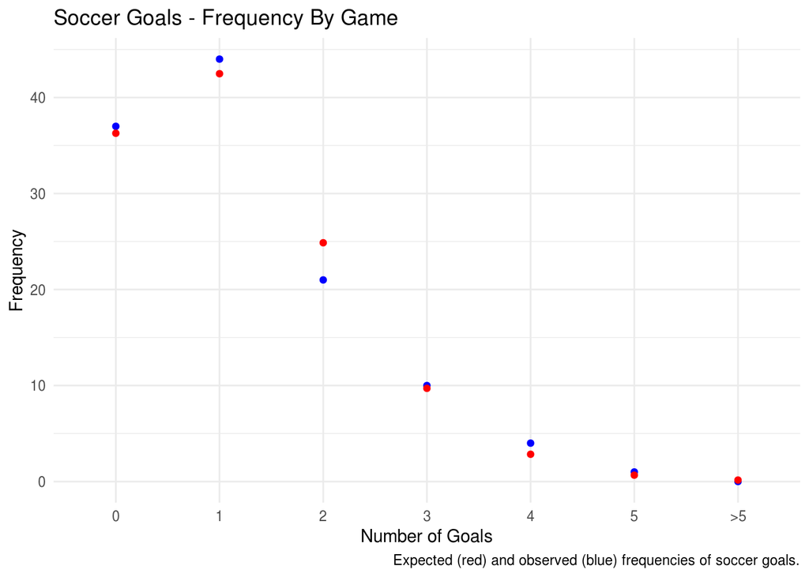

```r
ggplot(data = soccer) +
  geom_point(aes(x = goals, y = freq),
            col = "blue") +
  geom_point(aes(x = goals, y = expected),
            col = "red") +
  theme_minimal() +
  ggtitle("Soccer Goals - Frequency By Game") +
  xlab("Number of Goals") +
  ylab("Frequency") +
  labs(caption = "Expected (red) and observed (blue) frequencies of soccer goals.")
```

#### e) If skill differences do not matter, would you expect the variance in the number of goals per team and side to be less than, equal to, or greater than the mean number of goals? Calculate the variance in the number of goals per team and side. How similar is this to the mean?

For a poisson distribution (which the data should resemble, if the goals are random) the variance and mean should both be equal to $\lambda$.

```r
real_goals <- c(rep(0,soccer[1,]$freq),
                rep(1,soccer[2,]$freq),
                rep(2,soccer[3,]$freq),
                rep(3,soccer[4,]$freq),
                rep(4,soccer[5,]$freq),
                rep(5,soccer[6,]$freq))

exp_goals <-  c(rep(0,soccer[1,]$expected),
                rep(1,soccer[2,]$expected),
                rep(2,soccer[3,]$expected),
                rep(3,soccer[4,]$expected),
                rep(4,soccer[5,]$expected),
                rep(5,soccer[6,]$expected))
var(exp_goals)
```

```
## [1] 1.006479
```

```r
mean(exp_goals)
```

```
## [1] 1.106195
```

```r
goal_var <- var(real_goals)
```

### 4) Coin Flips

**One thousandcoins were each flipped eight times, and the number of heads was recorded for each coin. The results are as follows:**

```r
coins <- data.frame(heads = 0:8,
                    coins = c(6, 32, 105, 186, 236, 201, 98, 33, 103))

kable(coins) %>% kable_styling()
```

| heads | coins |
| --- | --- |
| 0 | 6 |
| 1 | 32 |
| 2 | 105 |
| 3 | 186 |
| 4 | 236 |
| 5 | 201 |
| 6 | 98 |
| 7 | 33 |
| 8 | 103 |

#### a) Test whether the distribution of coin flips matches the expected frequencies from a binomial distribution assuming all fair coins.

```r
coins$expected <- dbinom(0:8, size=8, prob=0.5)

coin_test <- chisq.test(coins$coins, p=coins$expected)
```

Based on our test, we **are able to reject the null hypothesis that the coin flips behaved as expected** in this experiment ($\chi^2$(8) = 2527.8756571, p-value = 0).

#### b) If the binomial distribution is a poor fit to the data, identify in what way the distribution does not match the expectation.

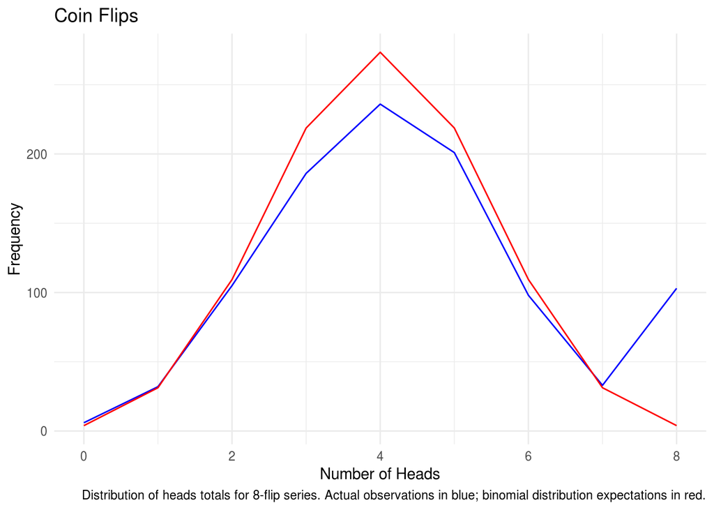

```r
ggplot(data = coins) +
  geom_line(aes(x = heads, y = coins),
            col = "blue") +
  geom_line(aes(x = heads, y = expected*sum(coins)),
            col = "red") +
  theme_minimal() +
  ggtitle("Coin Flips") +
  xlab("Number of Heads") +
  ylab("Frequency") +
  labs(caption = "Distribution of heads totals for 8-flip series. Actual observations in blue; binomial distribution expectations in red.")
```

There is a clear problem with the binomial distribution comparison here - our data have a shockingly large, unexpected number of eight-heads events! These should be very rare but actually occurred 10.3% of the time.

#### c) Some two-headed coins (which always show heads on every flip) were mixed in with the fair coins. Can you say approximately how many two-headed coins there might have been out of this 1000?

Given a bunch of normal coins and also a few two-headed coins, the expected number of 8-heads events changes to:

$$P(8) = \frac{(1000 - x) }{2^8} + x$$

where x is the number of two-headed coins. Given this and the actual number of 8-heads events (103), we can solve for x:

$$x = \frac{103 - 1000 \times 2^{-8}}{1 - 2^{-8}}$$

From here, we get that there were 99.4823529 two-headed coins, which rounds to **99**.

### 5) Hurricanes

**Hurricanes hit the United States often and hard, causing some loss of life and enormous economic costs. They are ranked in severity by the Saffir-Simpson scale, which ranges from Category 1 to Category 5, with 5 being the worst. In some years, as many as three hurricanes that rate a Category 3 or higher hit the US coastline. In other years, no hurricane of this severity hits the United States. The following table lists the number of years that had 0, 1, 2, 3, or more hurricanes of at least Category 3 in severity, over the 100 years of the 20thcentury (Blake et al., 2005).**

```r
hurricanes <- data.frame(hurricanes = c("0","1","2","3",">3"),
                         freq = c(50,39,7,4,0))
kable(hurricanes) %>% kable_styling()
```

| hurricanes | freq |
| --- | --- |
| 0 | 50 |
| 1 | 39 |
| 2 | 7 |
| 3 | 4 |
| >3 | 0 |

#### a) What is the mean number of severe hurricanes to hit the United States per year?

```r
mean_hurricanes <- sum((0:3) * hurricanes$freq) / sum(hurricanes$freq)
```

The average number of severe hurricanes (Category 3 or higher) that hit the US in a year is **0.65**.

#### b) What model would describe the distribution of hurricanes per year, if they were to hit independently of each other and if the probability of a hurricane were the same every year?

The **Poisson** distribution.

#### c) Test the fit of the model for part (b) to the data.

```r
hurricanes$expected <- dpois(0:4, mean_hurricanes)
hurricanes[5,]$expected <- (1-ppois(3,mean_hurricanes))

hurricane_test <- chisq.test(hurricanes$freq, p=hurricanes$expected/sum(hurricanes$expected))
```

Based on our test, we **were not able to reject the null hypothesis that hurricanes are distributed randomly** in time ($\chi^2$(4) = 3.851434, p-value = 0.4264853).

### 6) Ear Preference

**Do people typically use a particular ear preferentially when listening to strangers? Marzoli and Tomassi (2009) had a researcher approach and speak to strangers in a noisy nightclub. An observer scored whether the person approached turned either the left or the right ear toward the questioner. Of 25 participants, 19 turned the right ear toward the questioner and 6 offered the left ear. Is this evidence of population difference from 50% for each ear? Use the following steps to help answer this question with a binomial test. Consider that the assumptions of the binomial test are met in this study.**

#### a) State the null and alternative hypotheses.

$H_o$: Participants show no preference between ears presented to strangers. $H_a$: Participants show a preference between ears presented to strangers.

#### b) What is the observed value of the test statistic?

The test statistic is the number of right ear users, which here is 19.

#### c) Under the null hypothesis, calculate the probability of getting exactly 19 right ears and six left ears.

If there were equal chances of the right or left ear being used, the probability of getting exactly 19 right ears and 6 left would be:

```r
dbinom(19, size=25, prob=0.5)
```

```
## [1] 0.005277991
```

#### d) List all possible outcomes in which the number of right ears is greater than the 19 observed.

```r
more_than_19 <- data.frame(right = c(20,21,22,23,24,25),
                           left = c(5,4,3,2,1,0))

kable(more_than_19) %>% kable_styling()
```

| right | left |
| --- | --- |
| 20 | 5 |
| 21 | 4 |
| 22 | 3 |
| 23 | 2 |
| 24 | 1 |
| 25 | 0 |

#### e) Calculate the probability under the null hypothesis of each of the extreme outcomes listed in (d).

```r
more_than_19$probability <- dbinom(more_than_19$right, size=25, prob=0.5)

kable(more_than_19) %>% kable_styling()
```

| right | left | probability |
| --- | --- | --- |
| 20 | 5 | 0.0015834 |
| 21 | 4 | 0.0003770 |
| 22 | 3 | 0.0000685 |
| 23 | 2 | 0.0000089 |
| 24 | 1 | 0.0000007 |
| 25 | 0 | 0.0000000 |

#### f) Calculate the probability of 19 or more right-eared turns under the null hypothesis.

```r
more_than_19_prob <- sum(dbinom(19:25, size=25, prob=0.5))
```

The chance of there being at least 19 instances of right ears being used is only **0.7316649%**.

#### g) Give the two-tailed P-value based on your answer to (f).

The chance of there being at least 19 instances of right ears being used or fewer than 7 instances is only **1.4633298%**.

#### h) Interpret this P-value. What does it indicate?

It gives the chance of there being at least 19 right ear uses or fewer than 7.

#### i) State the conclusion from your test.

Because our p-value is less than $\alpha = 0.05$, we can reject the null hypothesis that people show no preference in the ear they turn towards strangers. There does appear to be a preference here.

### 7) Hypothesis Testing

**Assume that a null hypothesis is true. Which one of the following statements is true?

1. A study with a larger sample is more likely than a smaller study to get the result that P < 0.05.
2. A study with a larger sample is less likely than a smaller study to get the result that P < 0.05.
3. A study with larger sample is equally likely compared to a smaller study to get the result that P < 0.05.

For many statistical tests, use of very large sample sizes will often return ‘significant’ results with p << 0.05 even for cases where the actual distribution diverges only very slightly from the expected test distribution.

For cases with very small sample sizes it may be difficult to achieve the statistical power required to reject the null (P < 0.05) even in situations where the difference is actually significant (i.e. a false negative). But very small sample sizes are also more likely to ‘successfully’ reject the null in cases where there is no actual effect (false positive).

Studies based on small sample sizes are more likely to return erroneous results due to random chance than are studies based on large sample sizes, but whether this means that they are more likely to find that P < 0.05 depends on whether the underlying effect being investigated actually exists.

### 8) Error Types

Assume a random sample. What effect does increasing the sample size have on:

#### b) The probability of committing a Type II error?

Decreases.

#### c) The significance level?

Remains unchanged.

### 9) the Right Hand of Toad

**In the toad experiment we looked at in the class, what would the P-value have been if**

```r
num_toads <- 18
p_15 <- (1 - pbinom(15, size=num_toads, prob=0.5))*2
p_13 <- (1 - pbinom(13, size=num_toads, prob=0.5))*2
p_10 <- (1 - pbinom(10, size=num_toads, prob=0.5))*2
p_07 <- pbinom(7, size=num_toads, prob=0.5)*2
```

#### a) 15 toads were right-handed and the rest were left-handed?

**0.0013123**

#### b) 13 toads were right-handed and the rest were left-handed?

**0.0308838**

#### c) 10 toads were right-handed and the rest were left-handed?

**0.4806824**

#### d) 7 toads were right-handed and the rest were left-handed?

**0.4806824**